# Intro to Data Science for Risk Managers and Trading Professionals

# Why Data Science?

- Risk Managers and Trading Professionals = Decision Engineers
- Data Science is a science behind getting to better decisions
- Data Science is about generating hypothesis and testing
- Data Science is about identifying causal relationship between different market factors

# Our Objective

- Risk Managers can benefit greatly from the world of Data Science
- Data Science from a the Risk Manager/Trading Professional perspective
- The objective is to give a small glimpse into possibilities
- This is going to introductory and 101 and we hope to build on this through community feedback

# What is some of the use cases in Risk Management

- Outlier Detections and Regime Switching
- Generating Stress Scenarios
- Visualizing Market Relationships
- Developing Prediciton Models

# Data Science Approach

- Data Science is about uncovering unknowns
- Experimentation and Validated Learing
- Lean Approach and (1) Build (2) Measure (3) Learn Cycle
- Fast cycle development requires fit-for-purpose tools

# Tools and Resources

- Cloud Platform
- Scalable and flexible data environment
- Raw Data at your fingertips is 80% of the work
- Open Source tools with large user community

# What do I use and Why?

- R is one of the most popular tools of Data Scientists
- R is open source with large user community
- Single interface and many tools
- Rich statistical library sets

# How to use R and Setup for the sessions

- Power of R is in Packages
- RStudio IDE: [www.rstudio.com]

# Data Science Approach and Risk Management Example

- Ingesting Data from an API
- Cleaning Data
- Exploratory Visualization
- Descriptive Statistics
- Predictive Models
- Deploy the tools as an online app

# BitCoin/Crypto Currency Example

- BitCoins potentially new asset class
- BitCoins are completely new to me no previous experience and bias
- We have three currency pairs (1) CAD/BTC (2) US/BTC and (3) EUR/BTC how do we use Data Science to learn about this market and possibly develop a trading model
- This problem is more about journy and learning than outcome

# Flavour of what is to come!

```r
summary(cars)
```

```
##      speed           dist
##  Min.   : 4.0   Min.   :  2.00
##  1st Qu.:12.0   1st Qu.: 26.00
##  Median :15.0   Median : 36.00
##  Mean   :15.4   Mean   : 42.98
##  3rd Qu.:19.0   3rd Qu.: 56.00
##  Max.   :25.0   Max.   :120.00
```

# Data Viz as Exploratory tool

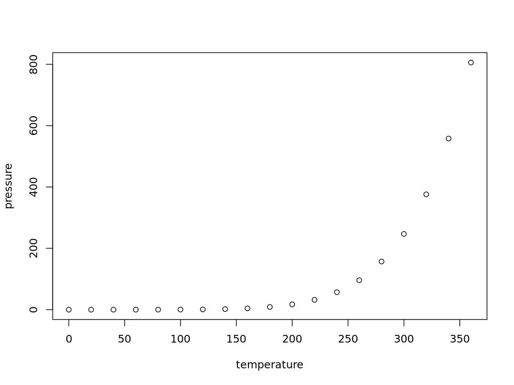